# Unit 4: prob dists in R

## Probability Distributions in R

As an example in R we will work with the normal distribution

In my opinion, alot of things are **easier** in R

**`dnorm(x,mean = 0,sd = 1)`** gives prob *densities* over \(X\)

**`rnorm(n,mean = 0,sd = 1)`** gives you \(n\) samples

**`pnorm(x,mean = 0,sd = 1)`** gives you the cdf of \(F(X)\)

**`qnorm(p,mean = 0,sd = 1)`** gives you quantiles \(F^{-1}(p)\)

If you don’t know what quantiles are, or you don’t understand what \(F^{-1}(p)\) means, don’t worry! We will cover this topic separately later in the course (Q-Q plots)

## `dnorm` - get the probabilities

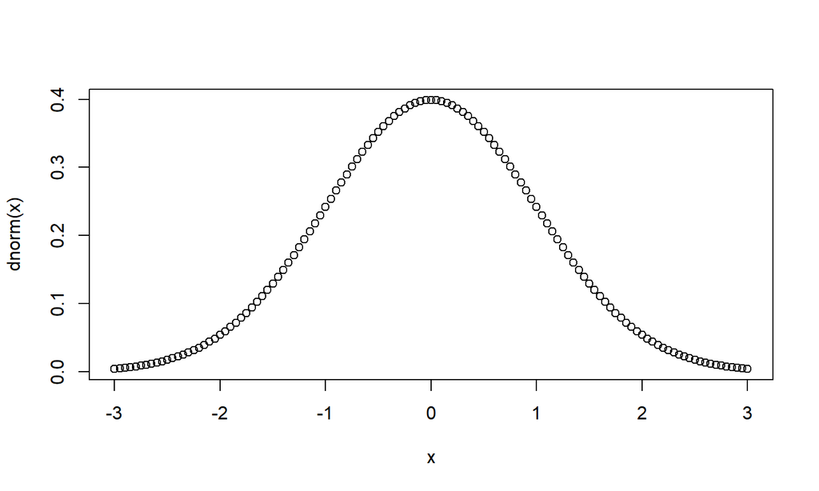

```r
x = seq(-3,3,by=0.05)  # choose the range of X
plot(x,dnorm(x))      # the prob densities P(X)
```

## `rnorm` - get n samples

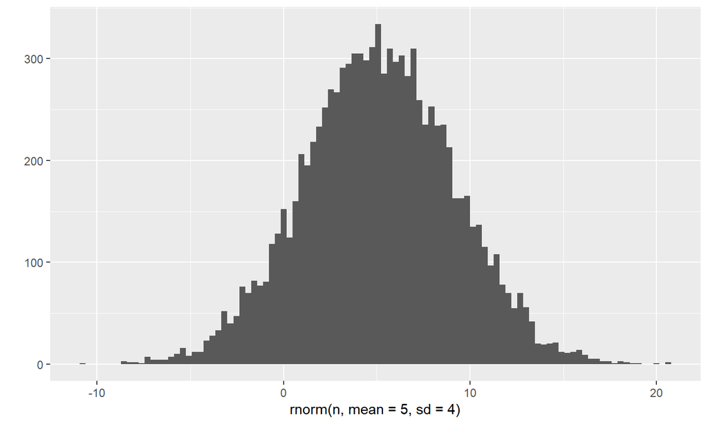

```r
n = 10000
qplot(rnorm(n,mean=5,sd=4),geom='histogram',bins=100)
```